# Case Study 2

Christian

# # Project Presentation

https://smu.zoom.us/rec/share/_PzRRtfdhT2ePWzXH0Lx2sIZMq8GwgeKTA2HAVasKvkCtHDZZRhChZdbOfmoVHVZ.ew57SCDdjbvTRiCs?startTime=1702429652000 Passcode: rdV076=w

CDCastr0.github.io/pro

## Preparing the Environment and Loading the Data

This is loading the necessary libraries like readr, dplyr, tidyr, ggplot2, caret, e1071, and class.

```r
# Load libraries
library(rmarkdown)
library(readr)
library(dplyr)
library(tidyr)
library(caret)
library(e1071)
```

```r
library(class)
library(ggplot2)


# Load data
data <- read.csv(choose.files())
```

```r
# Convert categorical variables to factors
data$Attrition <- factor(data$Attrition, levels = c("No", "Yes"), labels = c(0, 1))
data$BusinessTravel <- factor(data$BusinessTravel)
data$Department <- factor(data$Department)
data$EducationField <- factor(data$EducationField)
data$Gender <- factor(data$Gender)
data$JobRole <- factor(data$JobRole)
data$MaritalStatus <- factor(data$MaritalStatus)
data$Over18 <- factor(data$Over18)
data$OverTime <- factor(data$OverTime)
```

```r
# Convert factors to numeric for correlation analysis
data_numeric <- data %>%
  mutate(across(where(is.factor), as.numeric))

# Remove constant variables
data_numeric <- data_numeric %>% select_if(~sd(.) != 0)
```

# # Exploratory Data Analysis

To begin, we started by analyzing the correlation between all variables. This produced a correlation matrix used to reference different variables in the selection process.

```r
# Perform correlation analysis
correlation <- cor(data_numeric, use = "complete.obs")

# Sort the correlation with Attrition and find the top factors
sorted_correlation <- sort(correlation['Attrition',], decreasing = TRUE)

# Display the top factors (excluding Attrition itself)
sorted_correlation[sorted_correlation != 1][1:3]
```

```
##      OverTime MaritalStatus       JobRole
##     0.2720366     0.1970150     0.0905386
```

We next plotted different graphs in order to understand how the variables related to each other.

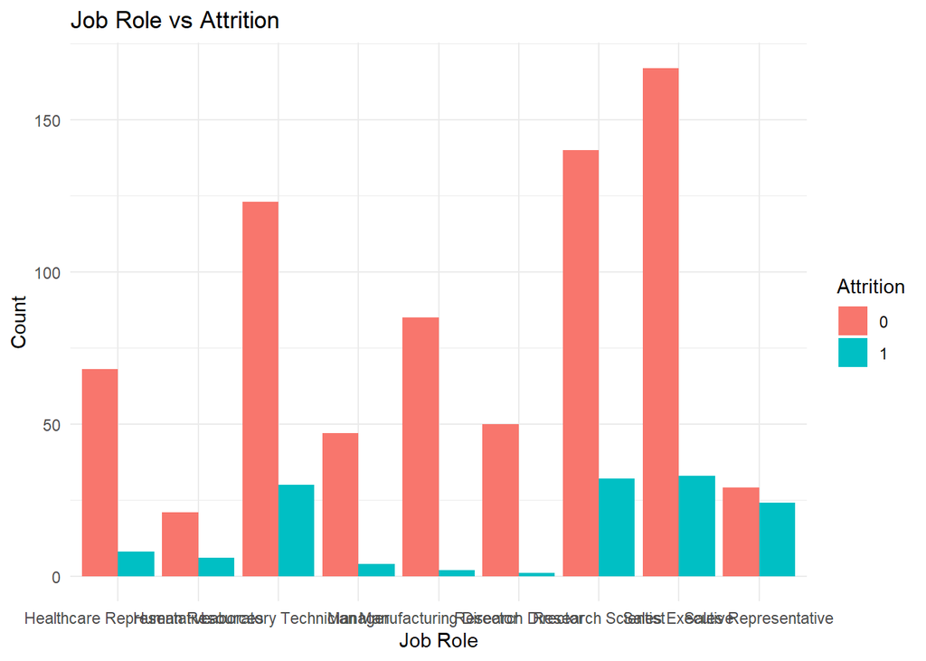

```r
ggplot(data, aes(x = JobRole, fill = Attrition)) +
  geom_bar(position = "dodge") +
  labs(title = "Job Role vs Attrition", x = "Job Role", y = "Count") +
  theme_minimal()
```

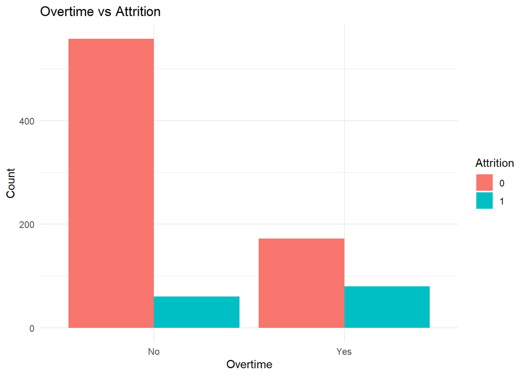

```r
ggplot(data, aes(x = OverTime, fill = Attrition)) +
  geom_bar(position = "dodge") +
  labs(title = "Overtime vs Attrition", x = "Overtime", y = "Count") +
  theme_minimal()
```

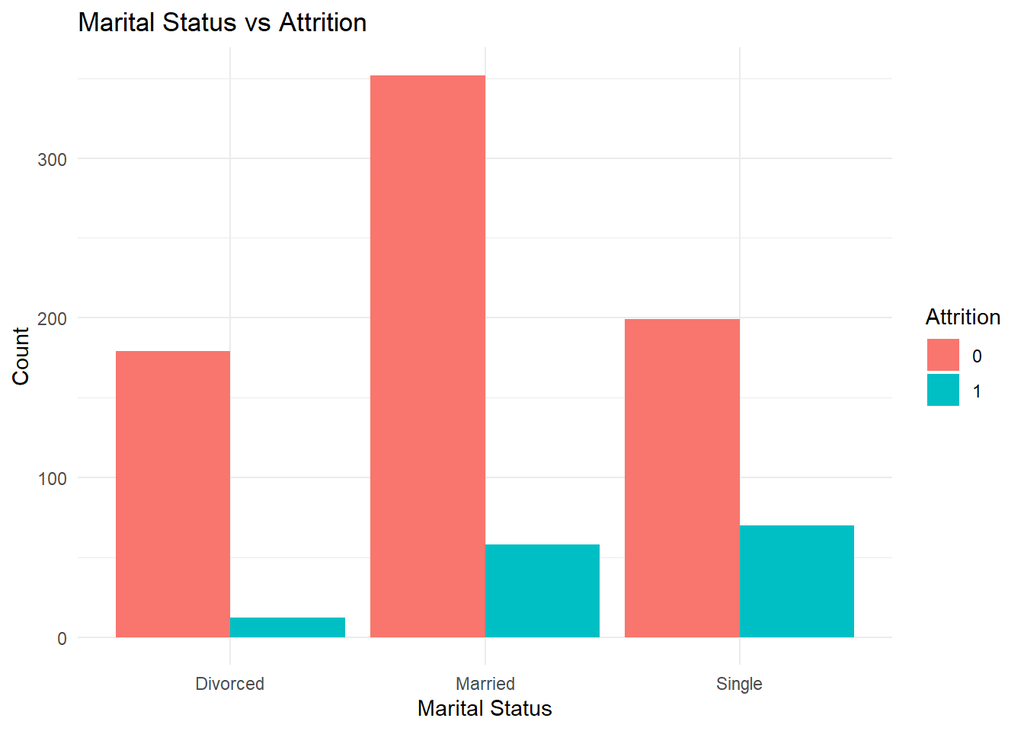

```r
ggplot(data, aes(x = MaritalStatus, fill = Attrition)) +
  geom_bar(position = "dodge") +
  labs(title = "Marital Status vs Attrition", x = "Marital Status", y = "Count") +
  theme_minimal()
```

```r
# Visualizing correlations
#correlation_plot <- cor(data %>% select_if(is.numeric))
#ggplot(data = as.data.frame(correlation_plot), aes(x = Var1, y = Var2, fill = value)) +
  geom_tile()
```

```
## geom_tile: linejoin = mitre, na.rm = FALSE
## stat_identity: na.rm = FALSE
## position_identity
```

```r
# Identifying top factors for attrition
#attrition_factors <- data %>%
#  group_by(attrition) %>%
#  summarise_all(funs(mean(., na.rm = TRUE)))
#Analyzing the distribution of attrition across different departments
#ggplot(data, aes(x = Department, fill = Attrition)) +
#  geom_bar(position = "fill") +
#  labs(title = "Attrition Distribution Across Departments", x = "Department", y = "Proportion")


# Exploring the relationship between job satisfaction and attrition
#ggplot(data, aes(x = JobSatisfaction, fill = Attrition)) +
#  geom_bar(position = "fill") +
#  labs(title = "Job Satisfaction vs Attrition", x = "Job Satisfaction Level", y = "Proportion")

# Relationship between total working years and attrition
#ggplot(data, aes(x = TotalWorkingYears, y = after_stat(count), fill = Attrition)) +
#  geom_histogram(binwidth = 1, position = "dodge") +
#  labs(title = "Total Working Years vs Attrition", x = "Total Working Years", y = "Count")

# Plotting histogram of a variable (example: Age)
#ggplot(data, aes(x = Age)) + geom_histogram(bins = 30) + theme_minimal()

# Exploring relationship between two variables (example: Age and Attrition)
#ggplot(data, aes(x = Age, fill = Attrition)) + geom_histogram(bins = 30) + theme_minimal()

# Analyzing the distribution of attrition across different departments
#ggplot(data, aes(x = Department, fill = Attrition)) +
#  geom_bar(position = "fill") +
#  labs(title = "Attrition Distribution Across Departments", x = "Department", y = "Proportion")

# Exploring the relationship between job satisfaction and attrition
#ggplot(data, aes(x = JobSatisfaction, fill = Attrition)) +
#  geom_bar(position = "fill") +
#  labs(title = "Job Satisfaction vs Attrition", x = "Job Satisfaction Level", y = "Proportion")

# Relationship between total working years and attrition
#ggplot(data, aes(x = TotalWorkingYears, y = after_stat(count), fill = Attrition)) +
#  geom_histogram(binwidth = 1, position = "dodge") +
#  labs(title = "Total Working Years vs Attrition", x = "Total Working Years", y = "Count")

# Analyzing job role specific trends in job satisfaction
#ggplot(data, aes(x = JobRole, y = JobSatisfaction)) +
#  geom_boxplot() +
#  labs(title = "Job Satisfaction Across Different Job Roles", x = "Job Role", y = "Job Satisfaction Level") +
#  theme(axis.text.x = element_text(angle = 45, hjust = 1))

# Job role specific attrition trends
#ggplot(data, aes(x = JobRole, fill = Attrition)) +
#  geom_bar(position = "fill") +
#  labs(title = "Attrition Rates Across Different Job Roles", x = "Job Role", y = "Proportion") +
#  theme(axis.text.x = element_text(angle = 45, hjust = 1))

# Age distribution with respect to attrition
#ggplot(data, aes(x = Age, fill = Attrition)) +
#  geom_histogram(binwidth = 1, position = "dodge") +
#  labs(title = "Age Distribution vs Attrition", x = "Age", y = "Count")

# Exploring the impact of marital status on attrition
#ggplot(data, aes(x = MaritalStatus, fill = Attrition)) +
#  geom_bar(position = "fill") +
#  labs(title = "Marital Status vs Attrition", x = "Marital Status", y = "Proportion")
```

Parts of the above EDA were generated by AI and were useful in coming up with creative graphs.

# # Analysis of Important Variables

Given the most highly correlated variables, we decided to proceed with a model that includes them in order to test it’s accuracy.

```r
data$Attrition
```

[output not shown]

```r
# Load the data
data <- read.csv(choose.files())

# Check the unique values in Attrition column
unique(data$Attrition)
```

```
## [1] "No"  "Yes"
```

```r
# Ensure Attrition is converted to a factor with correct levels
#data$Attrition <- factor(data$Attrition, levels = c("No", "Yes"))

# Convert other variables to factors
#data$OverTime <- factor(data$OverTime)
#data$JobRole <- factor(data$JobRole)
#data$MaritalStatus <- factor(data$MaritalStatus)

# Function to calculate attrition rates
#calculate_attrition_rate <- function(data, column_name) {
#  data %>%
#    group_by(!!sym(column_name)) %>%
#    summarise(Attrition_Count = sum(Attrition == "Yes", na.rm = TRUE),
#              Total_Count = n(),
#              Attrition_Rate = Attrition_Count / Total_Count) %>%
#    arrange(desc(Attrition_Rate))
#}

# Calculate attrition rates for Job Role, Overtime, and Marital Status
#job_role_attrition <- calculate_attrition_rate(data, "JobRole")
#overtime_attrition <- calculate_attrition_rate(data, "OverTime")
#marital_status_attrition <- calculate_attrition_rate(data, "MaritalStatus")

# Display the results
#job_role_attrition
#overtime_attrition
#marital_status_attrition
```

This did not yield a reliable or accurate model, so we began to search elsewhere for better variables.

# # T-tests and Variables

```r
# Load the data
data <- read.csv(choose.files())

# Ensure data$Attrition is a factor and check its levels
data$Attrition <- as.factor(data$Attrition)
print(levels(data$Attrition))  # Should output something like '0' and '1' or 'Yes' and 'No'
```

```
## [1] "No"  "Yes"
```

```r
# Identify numeric variables
numeric_vars <- sapply(data, is.numeric)
numeric_vars_names <- names(data)[numeric_vars]

# Initialize an empty data frame to store t-test results
t_test_results <- data.frame(Variable = character(),
                             p_value = numeric(),
                             mean_diff = numeric(),
                             stringsAsFactors = FALSE)

# Corrected code for handling variables with little or no variance within groups
for (var in numeric_vars_names) {
  # Perform t-test if the variable has more than one unique value in both groups
  if (length(unique(data[data$Attrition == levels(data$Attrition)[1], var])) > 1 &&
      length(unique(data[data$Attrition == levels(data$Attrition)[2], var])) > 1) {

    # Perform t-test
    t_test <- t.test(data[[var]] ~ data$Attrition)

    # Calculate mean difference
    mean_diff <- abs(diff(tapply(data[[var]], data$Attrition, mean, na.rm=TRUE)))

    # Append results to the data frame
    t_test_results <- rbind(t_test_results,
                            data.frame(Variable = var,
                                       p_value = t_test$p.value,
                                       mean_diff = mean_diff))
  }
}

# Order results by p-value
t_test_results <- t_test_results[order(t_test_results$p_value),]

# Display the results
print(t_test_results)
```

```
##                       Variable      p_value    mean_diff
## Yes11            MonthlyIncome 2.412488e-07 1.937214e+03
## Yes9                  JobLevel 4.041851e-07 4.807241e-01
## Yes18        TotalWorkingYears 6.595682e-07 3.417025e+00
## Yes22       YearsInCurrentRole 1.522152e-06 1.546282e+00
## Yes8            JobInvolvement 1.997298e-06 3.593933e-01
## Yes24     YearsWithCurrManager 5.084229e-06 1.427006e+00
## Yes17         StockOptionLevel 3.860043e-05 3.468689e-01
## Yes1                       Age 5.049764e-05 3.626614e+00
## Yes21           YearsAtCompany 2.563021e-04 2.108513e+00
## Yes10          JobSatisfaction 1.497265e-03 3.259295e-01
## Yes3          DistanceFromHome 1.640519e-02 1.928376e+00
## Yes20          WorkLifeBalance 1.900885e-02 1.738748e-01
## Yes6   EnvironmentSatisfaction 3.397271e-02 2.312133e-01
## Yes19    TrainingTimesLastYear 5.948323e-02 2.171233e-01
## Yes13       NumCompaniesWorked 9.788235e-02 4.182975e-01
## Yes4                 Education 1.421319e-01 1.375734e-01
## Yes                         ID 1.636497e-01 3.230577e+01
## Yes12              MonthlyRate 1.980950e-01 8.358376e+02
## Yes16 RelationshipSatisfaction 2.639669e-01 1.188845e-01
## Yes7                HourlyRate 2.744798e-01 2.001076e+00
## Yes2                 DailyRate 3.188749e-01 3.686742e+01
## Yes5            EmployeeNumber 4.978776e-01 3.749432e+01
## Yes15        PerformanceRating 6.610278e-01 1.497065e-02
## Yes14        PercentSalaryHike 6.692297e-01 1.532290e-01
## Yes23  YearsSinceLastPromotion 8.983165e-01 3.962818e-02
```

Given these results, we began to proceed with the new model.

```r
# Load the data
train_data <- read.csv(choose.files())
test_data <- read.csv(choose.files())

str(train_data)
```

```
## 'data.frame':    870 obs. of  36 variables:
##  $ ID                      : int  1 2 3 4 5 6 7 8 9 10 ...
##  $ Age                     : int  32 40 35 32 24 27 41 37 34 34 ...
##  $ Attrition               : chr  "No" "No" "No" "No" ...
##  $ BusinessTravel          : chr  "Travel_Rarely" "Travel_Rarely" "Travel_Frequently" "Travel_Rarely" ...
##  $ DailyRate               : int  117 1308 200 801 567 294 1283 309 1333 653 ...
##  $ Department              : chr  "Sales" "Research & Development" "Research & Development" "Sales" ...
##  $ DistanceFromHome        : int  13 14 18 1 2 10 5 10 10 10 ...
##  $ Education               : int  4 3 2 4 1 2 5 4 4 4 ...
##  $ EducationField          : chr  "Life Sciences" "Medical" "Life Sciences" "Marketing" ...
##  $ EmployeeCount           : int  1 1 1 1 1 1 1 1 1 1 ...
##  $ EmployeeNumber          : int  859 1128 1412 2016 1646 733 1448 1105 1055 1597 ...
##  $ EnvironmentSatisfaction : int  2 3 3 3 1 4 2 4 3 4 ...
##  $ Gender                  : chr  "Male" "Male" "Male" "Female" ...
##  $ HourlyRate              : int  73 44 60 48 32 32 90 88 87 92 ...
```

[output cut: 22 more lines]

```r
# Select relevant columns and convert factors (modify as per your top factors)
#train_data <- train_data %>%
#  select(Attrition, OverTime, JobRole, MaritalStatus) %>%
#  mutate(OverTime = factor(OverTime),
#         Attrition = factor(Attrition, levels = c("No", "Yes")))

# Select relevant columns and convert factors (modify as per your top factors)
#train_data <- train_data %>%
#  select(Attrition, MonthlyIncome, JobLevel, TotalWorkingYears) %>%
#  mutate(MonthlyIncome = factor(MonthlyIncome),
#         Attrition = factor(Attrition, levels = c("No", "Yes")))


# Assuming MonthlyIncome is already loaded in your data frame
# First, check the range of MonthlyIncome
range(train_data$MonthlyIncome)
```

```
## [1]  1081 19999
```

```r
# Now, create the breaks for the intervals
min_income <- min(train_data$MonthlyIncome, na.rm = TRUE)
max_income <- max(train_data$MonthlyIncome, na.rm = TRUE)
breaks <- seq(from = min_income, to = max_income, by = 100)

# Use cut function to create a new factor variable
train_data$IncomeGroup <- cut(train_data$MonthlyIncome, breaks = breaks, include.lowest = TRUE, right = FALSE)

# Display the structure to see the changes
str(train_data$IncomeGroup)
```

```
##  Factor w/ 189 levels "[1.08e+03,1.18e+03)",..: 34 186 83 94 27 78 11 57 12 40 ...
```

```r
# Optional: Convert IncomeGroup to a numeric code if needed
train_data$IncomeGroupCode <- as.numeric(train_data$IncomeGroup)

# Display the first few rows of the dataset to verify
head(train_data)
```

```
##   ID Age Attrition    BusinessTravel DailyRate             Department
## 1  1  32        No     Travel_Rarely       117                  Sales
## 2  2  40        No     Travel_Rarely      1308 Research & Development
## 3  3  35        No Travel_Frequently       200 Research & Development
## 4  4  32        No     Travel_Rarely       801                  Sales
## 5  5  24        No Travel_Frequently       567 Research & Development
## 6  6  27        No Travel_Frequently       294 Research & Development
##   DistanceFromHome Education   EducationField EmployeeCount EmployeeNumber
## 1               13         4    Life Sciences             1            859
## 2               14         3          Medical             1           1128
## 3               18         2    Life Sciences             1           1412
## 4                1         4        Marketing             1           2016
## 5                2         1 Technical Degree             1           1646
## 6               10         2    Life Sciences             1            733
##   EnvironmentSatisfaction Gender HourlyRate JobInvolvement JobLevel
```

[output cut: 48 more lines]

```r
train_data <- train_data %>%
  select(Attrition, MonthlyIncome, JobLevel, TotalWorkingYears) %>%
  mutate(MonthlyIncome = factor(MonthlyIncome),
         Attrition = factor(Attrition, levels = c("No", "Yes")))


#Previous test with correlation-determined variables
#test_data <- test_data %>%
#  select(OverTime, JobRole, MaritalStatus) %>%
#  mutate(OverTime = factor(OverTime))

test_data <- test_data %>%
  select(MonthlyIncome, JobLevel, TotalWorkingYears) %>%
  mutate(MonthlyIncome = factor(MonthlyIncome))

# Splitting the training data
set.seed(123)  # for reproducibility
training_indices <- createDataPartition(train_data$Attrition, p = 0.8, list = FALSE)
training_set <- train_data[training_indices, ]
validation_set <- train_data[-training_indices, ]

# Trying different values of k
k_values <- c(3, 5, 7, 9)
sensitivities <- c()
specificities <- c()

for (k in k_values) {
  knn_model <- knn3(Attrition ~ ., data = train_data, k = k)
  knn_pred <- predict(knn_model, validation_set, type = "class")
  conf_matrix <- confusionMatrix(knn_pred, validation_set$Attrition)
  sensitivities <- c(sensitivities, conf_matrix$byClass["Sensitivity"])
  specificities <- c(specificities, conf_matrix$byClass["Specificity"])
}

# Find the best k value
best_k <- k_values[which.max(sensitivities + specificities)]

# Training KNN model
knn_model <- knn3(Attrition ~ ., data = training_set, k = 15)

# Training Naive Bayes model
nb_model <- naiveBayes(Attrition ~ ., data = training_set)

# Ensure the validation set has the same structure as the training set
validation_set_formatted <- validation_set %>% select(-Attrition)

# Predicting on the validation set
knn_pred <- predict(knn_model, validation_set_formatted, type = "class")

# Check if the number of predictions matches the number of observations
if(length(knn_pred) != nrow(validation_set)) {
  stop("Number of predictions does not match the number of observations in the validation set.")
}

# Calculate confusion matrix and sensitivity, specificity
knn_conf_matrix <- confusionMatrix(knn_pred, validation_set$Attrition)
knn_sensitivity <- knn_conf_matrix$byClass["Sensitivity"]
knn_specificity <- knn_conf_matrix$byClass["Specificity"]

# Display KNN Sensitivity and Specificity
list(KNN_Sensitivity = knn_sensitivity, KNN_Specificity = knn_specificity)
```

```
## $KNN_Sensitivity
## Sensitivity
##           1
##
## $KNN_Specificity
## Specificity
##           0
```

```r
nb_pred <- predict(nb_model, validation_set)

# Calculate sensitivity and specificity
knn_conf_matrix <- confusionMatrix(knn_pred, validation_set$Attrition)
nb_conf_matrix <- confusionMatrix(nb_pred, validation_set$Attrition)

# Sensitivity and Specificity for KNN
knn_sensitivity <- knn_conf_matrix$byClass["Sensitivity"]
knn_specificity <- knn_conf_matrix$byClass["Specificity"]

# Sensitivity and Specificity for Naive Bayes
nb_sensitivity <- nb_conf_matrix$byClass["Sensitivity"]
nb_specificity <- nb_conf_matrix$byClass["Specificity"]

# Display results
list(KNN_Sensitivity = knn_sensitivity, KNN_Specificity = knn_specificity,
     NB_Sensitivity = nb_sensitivity, NB_Specificity = nb_specificity)
```

```
## $KNN_Sensitivity
## Sensitivity
##           1
##
## $KNN_Specificity
## Specificity
##           0
##
## $NB_Sensitivity
## Sensitivity
##   0.9863014
##
## $NB_Specificity
## Specificity
##  0.03571429
```

```r
# Predicting on test data (example with KNN)
test_predictions <- predict(knn_model, test_data)

# Output predictions
test_predictions
```

[output not shown]

[output cut: 856 more lines]

```r
data$OverTime
```

[output not shown]

[output cut: 58 more lines]

```r
# Assuming 'data' is your dataframe
data$OverTime <- as.factor(data$OverTime)  # Convert to factor if it's not
data$JobRole <- as.factor(data$JobRole)  # Convert to factor if it's not
data$MaritalStatus <- as.factor(data$MaritalStatus)  # Convert to factor if it's not

# Building the model
model <- lm(MonthlyIncome ~ OverTime + JobRole + MaritalStatus, data = data)

# Summary of the model to see coefficients and statistics
summary(model)
```

```
##
## Call:
## lm(formula = MonthlyIncome ~ OverTime + JobRole + MaritalStatus,
##     data = data)
##
## Residuals:
##     Min      1Q  Median      3Q     Max
## -5603.6 -1185.5  -422.4  1150.1  6846.8
##
## Coefficients:
##                               Estimate Std. Error t value Pr(>|t|)
## (Intercept)                    7395.68     267.57  27.640   <2e-16 ***
## OverTimeYes                      70.09     151.91   0.461    0.645
## JobRoleHuman Resources        -4145.07     451.47  -9.181   <2e-16 ***
## JobRoleLaboratory Technician  -4207.64     283.22 -14.856   <2e-16 ***
## JobRoleManager                 9764.88     365.14  26.743   <2e-16 ***
## JobRoleManufacturing Director    71.73     316.35   0.227    0.821
## JobRoleResearch Director       8311.58     364.73  22.788   <2e-16 ***
## JobRoleResearch Scientist     -4180.24     277.96 -15.039   <2e-16 ***
## JobRoleSales Executive         -542.60     271.56  -1.998    0.046 *
## JobRoleSales Representative   -4783.88     362.22 -13.207   <2e-16 ***
## MaritalStatusMarried             35.24     177.01   0.199    0.842
## MaritalStatusSingle               6.65     192.45   0.035    0.972
## ---
## Signif. codes:  0 '***' 0.001 '**' 0.01 '*' 0.05 '.' 0.1 ' ' 1
##
## Residual standard error: 2014 on 858 degrees of freedom
## Multiple R-squared:  0.8105, Adjusted R-squared:  0.8081
## F-statistic: 333.7 on 11 and 858 DF,  p-value: < 2.2e-16
```

# # Conclusion

Given the results of the t-test determined variables, the results were still disappointing. With hours of work put into researching models, and each of these models being no-good, there were no leads towards a better method, the deadline came and went without a good solution. This is not how I wanted this project to come out, nor how I imagined it would come out. This took hours upon hours, and even one all-nighter attempting to find a better way, but in the end, I was unable to do so.